# Opgave project

### K. Verbeeck, T. Vermeulen, J. Maervoet

Data Science (Theory) -- OGI02i

## Doelstelling project

Toon aan dat je de geziene leerstof en technieken beheerst

[figure not shown]

Hoe?

Het volledige data mining proces doorlopen

### Process

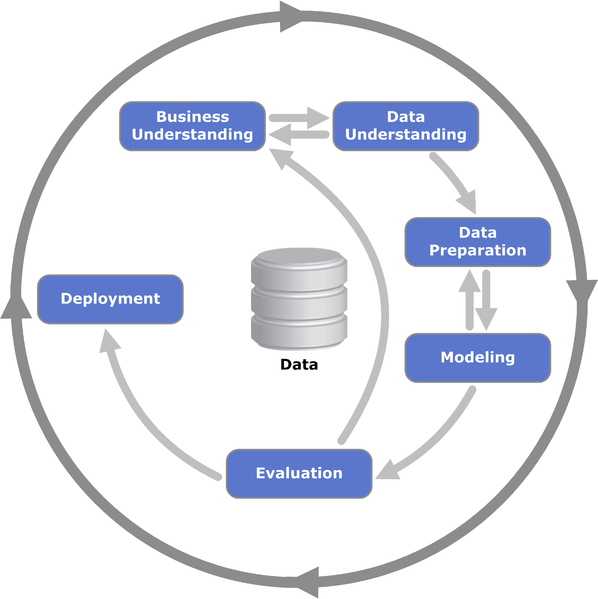

*Cross-industry standard process for data mining (CRISP-DM)*

## Evaluatiecriteria

1. Data inlezen en opkuisen
2. Data analyseren en in beeld brengen
3. Selectie features
4. Opstellen van meerdere modellen
5. Evaluatie en vergelijken van de gebruikte modellen
6. Rapporteren

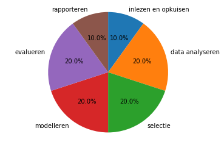

### 1. Data inlezen en opkuisen

- Data inlezen uit tekstbestand
- Tekstmanipulatie
- Datastructuren
- Filteren foute of overbodige data
- Features samenstellen
- Stel de data voor in een Pandas dataframe
- (Normalisatie)

### 2. Data analyseren en in beeld brengen

- Eigenschappen van de data voorstellen
  - Sorteren en groeperen
  - Berekenen (min, max, ...)
  - Overzicht in een tabel en subtabellen
  - Voorstellen in grafieken (bv.: Scatterplot)
- Bespreek de resultaten in je verslag
- Ook goeie pogingen waar je niets uit kon opmaken mogen in je verslag

### 2. Data analyseren en in beeld brengen

**Voorbeeld**

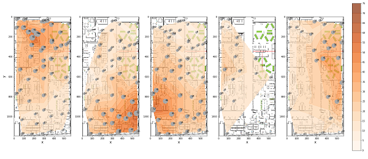

*Grafische weergave van de signaalsterkte per accespoint*

### 3. Selectie features

- Welke features geef je aan het model?
- Welke features lijken niet interessant?
- Welke zijn mogelijk misleidend (bv.: te hoge kans op overfitting)?
- Selectie op basis van analyses (vorige stap)
- Bespreek in je verslag wat je weglaat en waarom
  - Welke testen heb je gedaan?
  - Welke problemen zie je?
  - Waarom zijn bepaalde features interessant of waarom niet?

### 4. Opstellen van meerdere modellen

- Selecteer geschikte modellen  
  *(Eén model is niet voldoende)*
- Beargumenteer de keuze
- Doordachte keuzes en creätieve keuzes worden beloond

### 5. Evaluatie en vergelijken van de gebruikte modellen

- Test de verschillende modellen uit en vergelijk deze
- Experimenteer met de parameters van het model
- Doe een vergelijkende studie en geef de resultaten overzichtelijk weer
  - tabellen of figuren

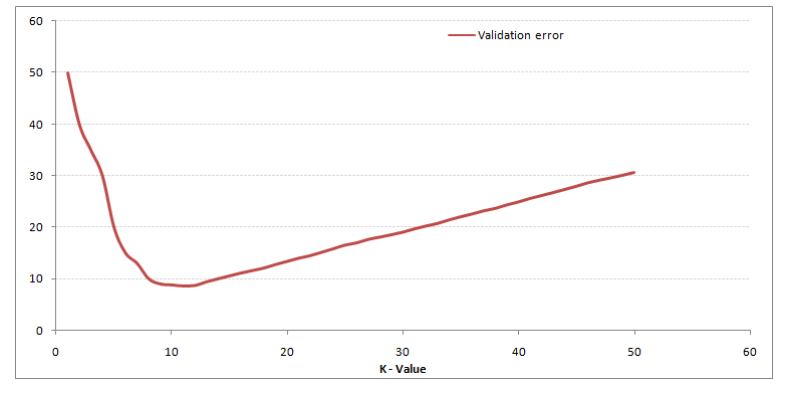

#### Effect van de seed op de score

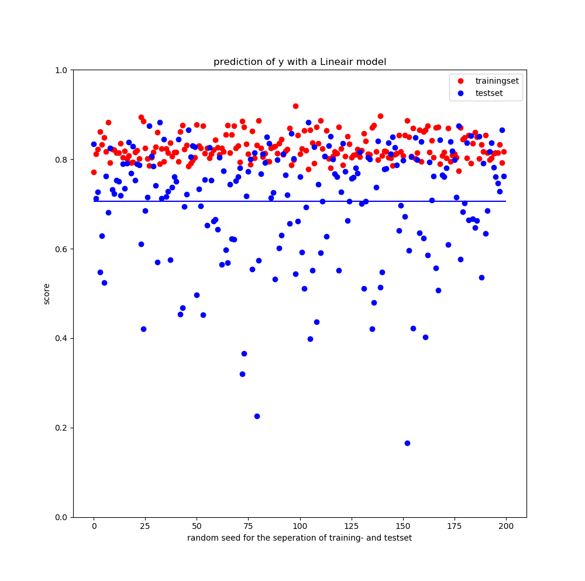

### 6. Rapporteren

- Verslag in Jupyter Notebook
- Alle stappen gevraagd in de evaluatie komen aan bod
- Zet je code in het verslag
- Genereer de nodige overzichten en grafieken
- Ook mislukte pogingen mogen in het verslag  
  (wel alleen compileerbare code)
- Geef een evaluatie van je resultaten
- Leg uit wat er te zien is en waarom je bepaalde dingen doet of toont
- Toon aan dat je de geziene theorie beheerst
- Wat is je besluit? Welk model presteert het best?
- Als je extra bronnen gebruikt, verwijs ernaar in je verslag

## Opgave

> Plaatsbepaling in de D gang gebruik makend van WiFi en een smartphone

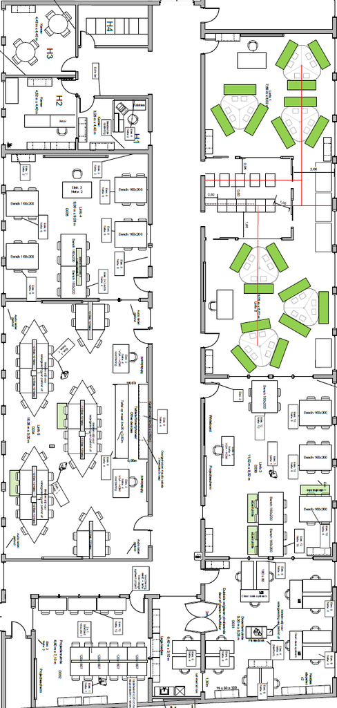

### Data

Metingen met een smartphone op een bepaald punt van de signaalsterkte van alle zichtbare accespoints

- **Time**: Tijdstip van de meting
- **Sender**: MAC-adres van het toestel waarop de meting werd uitgevoerd
- **Location**: Plaats waar de meting werd gedaan
  - **Lokaal**
  - **x** - en **y** -coördinaat: relatief t.o.v. het lokaal [0,1[
- **WifiInfo**: De gemeten signaalsterktes  
  *Voorbeeld: ODISEE@88-1d-fc-30-d4-40:-75*
  - **SSID**
  - **BSSID**
  - **signaalsterkte/verzwakking**

### Data

#### x- en y-coördinaat

- Linksboven is 0,0
- Rechtsonder is 1,1

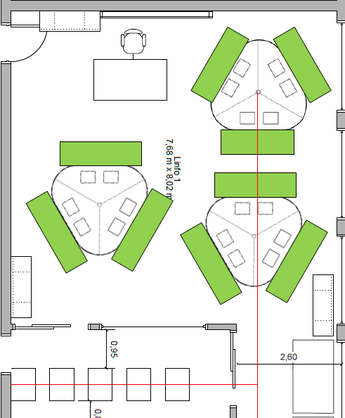

### Data

> **Time**=12/03 06:08:41& **Sender**=44:6E:E5:C5:8F:4F& **Location**=gang@0.65625;0.04449& **WifiInfo**=ODISEE@88-1d-fc-30-d4-40:-75,campusroam@88-1d-fc-30-d4-43:-73,ODISEE@88-1d-fc-30-d5-50:-78,eduroam@88-1d-fc-30-d4-42:-74,eduroam@88-1d-fc-30-d5-52:-78,campusroam@88-1d-fc-30-d5-53:-77,ODISEEGuest@88-1d-fc-30-d4-41:-75,ODISEEGuest@88-1d-fc-30-d5-51:-78,CiscoC5976@58-6d-8f-19-14-38:-82,rechts@58-6d-8f-19-10-fc:-51,ODISEE@88-1d-fc-41-dc-50:-67,eduroam@88-1d-fc-41-dc-52:-67,campusroam@88-1d-fc-41-dc-53:-67,eduroam@88-1d-fc-2c-c0-02:-73,campusroam@88-1d-fc-2c-c0-03:-71,ODISEE@88-1d-fc-2c-c0-00:-74,telenet-5467D@dc-53-7c-85-46-82:-87,ODISEEGuest@88-1d-fc-41-dc-51:-65,ODISEEGuest@88-1d-fc-2c-c0-01:-73,CiscoC5959@58-6d-8f-19-13-f4:-81,TELENETHOMESPOT@02-53-7c-85-46-83:-86

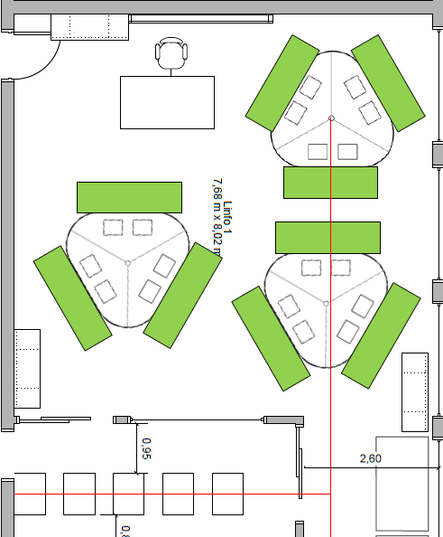

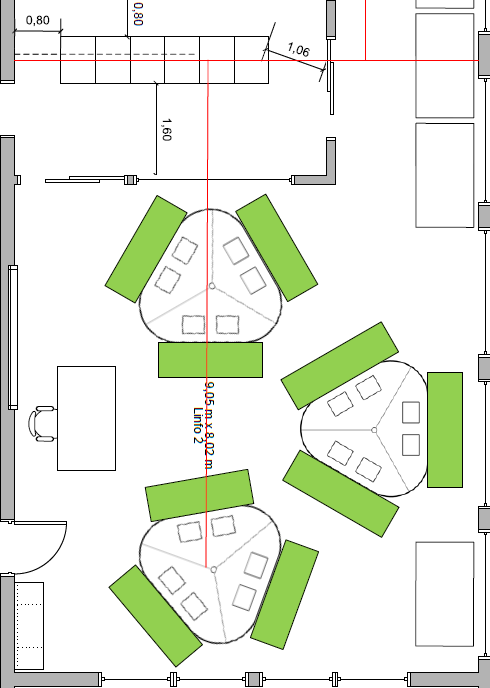

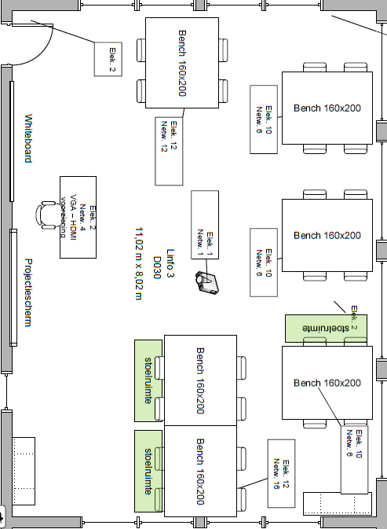

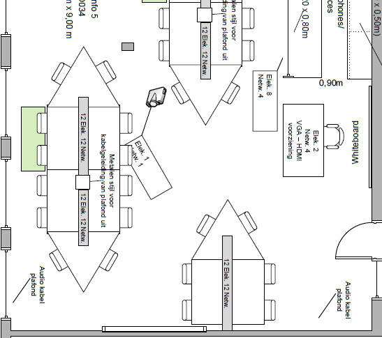

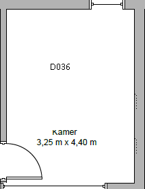

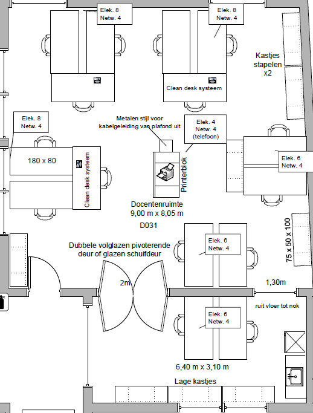

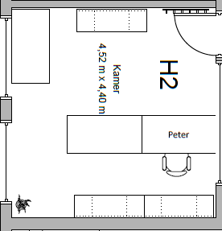

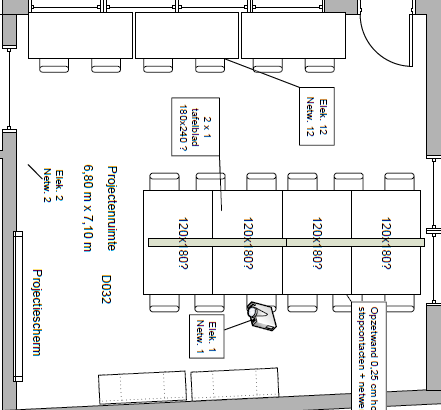

### Doel

- Een leermodel dat de locatie kan voorspellen op basis van de signaalsterktes van de aanwezige WiFi acces points, gemeten door een smartphone
- Voorspellen van:
  - Het lokaal
  - De x- en y-coördinaat
- Het halen van zo hoog mogelijke scores is niet het belangrijkste doel
- Het pad naar je eindresultaat is belangrijker
- Geen effectieve applicatie die plaatsbepaling kan doen

[figure not shown]

## Praktisch

### Deadline

> wo **29/05/2019** (is de dag voor hemelvaart = laatste lesdag)

Stuur je verslag (.ipynb) door via Toledo vóór de deadline

### Vereisten

- Je Notebook moet volledig en in volgorde uitvoerbaar zijn
- Alle nodige bestanden stuur je mee: gebruikte data, afbeeldingen, ...
- Je maakt zo veel mogelijk gebruik van de geziene leerstof:
  - Python
  - Numpy
  - Matplotlib
  - Pandas
  - scikit-learn

### Data

- Wij stellen straks een eerste bestand met data ter beschikking
  - Hierin zit data opgenomen gemeten door 2 verschillende toestellen
  - In het begin kan het eenvoudiger zijn om te werken met de data van één toestel
- Na een tijd stellen wij extra data ter beschikking
  - Onder andere data van een ander toestel
  - Je kan deze gebruiken om je modellen te testen
  - Of je kan deze ook bij je trainingsdata toevoegen, maar maak dan de vergelijking mét en zónder deze data
- Wij overwegen om jullie ook zelf data te laten verzamelen
  - Gevolg: veel diversere data
  - Eindresultaat zou beter bruikbaar moeten zijn
  - De leertaak wordt moeilijker, dus mogelijks minder goeie scores

### Puntenverdeling

- OLA Data Science Theorie [2 SP]
  - Schriftelijk Toledo examen (100%) - gesloten boek, zonder extra hulpmiddelen
- OLA Data Science Lab [3 SP]
  - Scantestjes afgenomen tijdens het labo (20 %)
  - Paper rond uitgewerkte case ingediend op het einde van het semester (80 %)

Veel succes!